# Univariate Inference_Week6

Author

Michael Cao

Published

February 15, 2025

**Hypothesis Test #1**

For the variable *widowed* from 2022 GSS (“If currently married, separated, or divorced: have you ever been widowed?”).

1. Assuming a null hypothesis of $p_{widowed} = 0.10$, or a reference value that 10% of the population has ever been widowed.
2. We set a generic alpha level $\alpha = 0.05$. This is the maximum risk we are willing to accept in making a Type 1 (false positive) error, or that we’re willing to falsely reject the null hypothesis 5% of the time.
3. $\hat{p}_{widowed} = 0.0322$; $\text{SE}_{widowed} = 0.00352$
4. $\frac{\left|\hat{p}_{\text{widowed}} - p_{\text{widowed}}\right|}{SE_{\text{widowed}}} = 19.261$ as our z-statistic. Immediately, this z-statistic stands out as extremely weird, as it suggests $\hat{p}_{widowed}$ is approximately 19 standard errors away from 0.10, which in my opinion is laughable.

```r
z_widowed <- 19.261
p_value_widowed <- 2 * (1 - pnorm(abs(z_widowed)))
p_value_widowed
```

```
[1] 0
```

Calculating a two-tailed p-value, our result is essentially 0, which means we can reject the null hypothesis of 0.10. It is beyond extreme that we would obtain our sample proportion given the expected value of the null distribution. Translating this to a confidence interval, the 95% confidence interval for this sample would be $\{0.0253, 0.0391\}$. This interval does not include 0.10, so alternatively, we can use it to reject the null hypothesis.

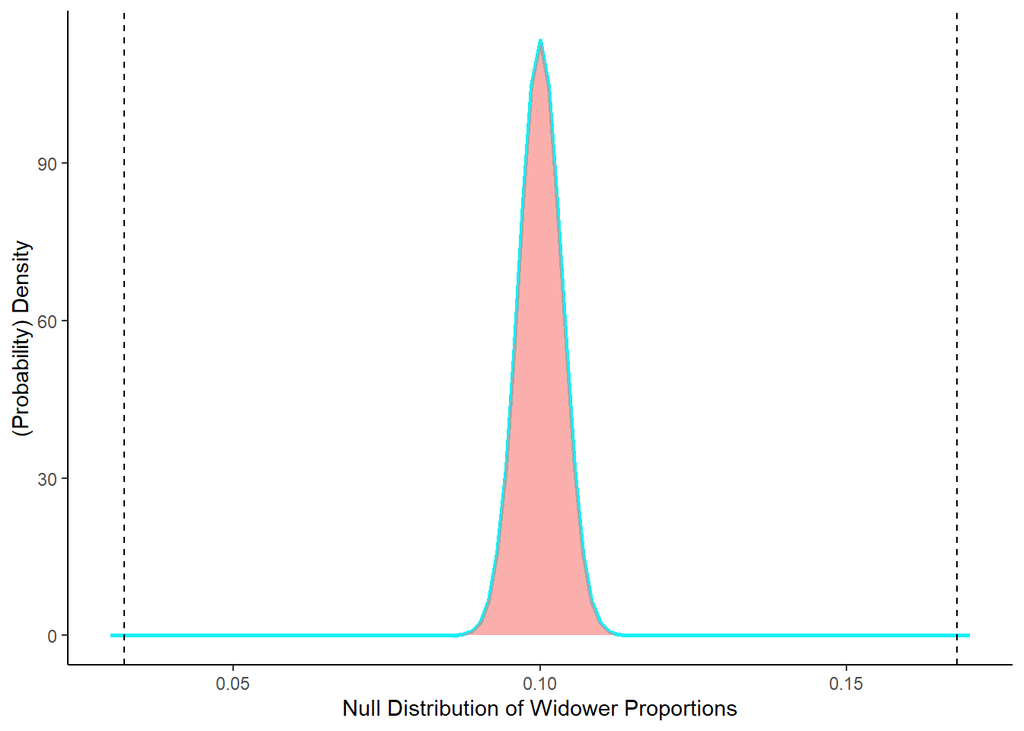

6. Visualizing the two-tailed hypothesis test, if the null hypothesis were true that 10% of our reference population is widowed, the probability of obtaining a sample statistic (as least as extreme as 3% of the sample being widowed) is essentially 0, as our p-value corresponds to an area in the tail-ends of the null distribution that is so small it is practically 0. Our observed result provides a lot of evidence against the null hypothesis.

**Hypothesis Test #2**

For the variable *pres16* from 2022 GSS (“Did you vote for Hillary Clinton?”).

```r
z_clinton <- 5.4
p_value_clinton <- 2 * (1 - pnorm(abs(z_clinton)))
p_value_clinton
```

```
[1] 6.66409e-08
```

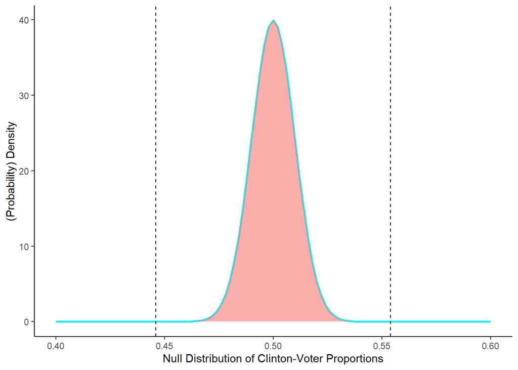

6. Visualizing the two-tailed hypothesis test, if the null hypothesis were true that 50% of our reference population voted for Hillary Clinton, the probability of obtaining a sample statistic (as least as extreme as 55% of the sample voting for Clinton) is essentially 0, as our p-value corresponds to an area in the tail-ends of the null distribution that is so small it is practically 0. Our observed result provides a lot of evidence against the null hypothesis.

**Hypothesis Test #3**

For the variable *weight* from the 2022 GSS (reported in pounds, without shoes, includes men and women).

```r
z_weight <- 4.768
p_value_weight <- 2 * (1 - pnorm(abs(z_weight)))
p_value_weight
```

```
[1] 1.860638e-06
```

Calculating a two-tailed p-value, our result is 0.00000186 (very close to 0), which means we can reject the null hypothesis of 180. It is extreme that we would obtain our sample mean given the expected value of the null distribution. Translating this to a confidence interval, the 99% confidence interval for this sample would be $\{182.3, 187.704\}$. This interval does not include 180, so alternatively, we can use it to reject the null hypothesis.

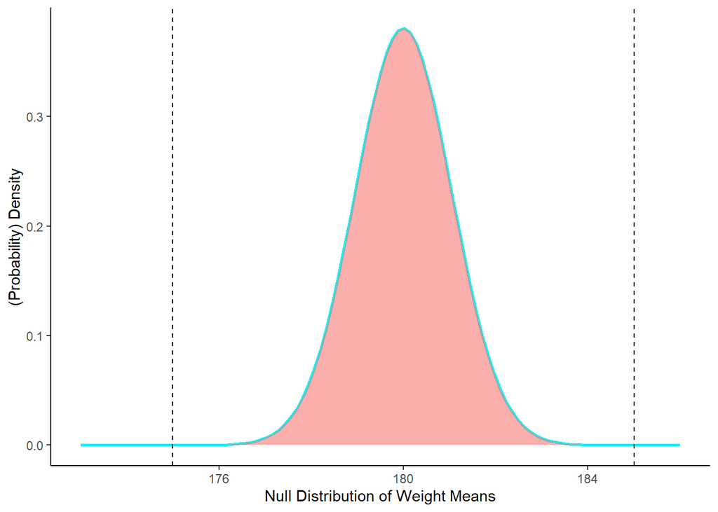

6. Visualizing the two-tailed hypothesis test, if the null hypothesis were true that the mean weight of our reference population was 180 pounds, the probability of obtaining a sample statistic (as least as extreme as the mean sample weight of 185 pounds) is essentially 0, as our p-value corresponds to an area in the tail-ends of the null distribution that is negligible. Our observed result provides a lot of evidence against the null hypothesis.

**Hypothesis Test #4**

For the variable *misswork* from 2022 GSS (“During the past 30 days, about how many days did you miss work due to your mental or physical health?”).

```r
z_misswork <- -0.449
p_value_misswork <- 2 * (1 - pnorm(abs(z_misswork)))
p_value_misswork
```

```
[1] 0.6534317
```

Calculating a two-tailed p-value, our result is 0.653, which is much higher than our alpha level, which we fail to reject the null hypothesis of 1. It is unsurprising/very likely that we would obtain our sample mean given the expected value of the null distribution. Translating this to a confidence interval, the 99% confidence interval for this sample would be $\{0.778, 1.156\}$. This interval does include 1, so alternatively, we can use it to fail to reject the null hypothesis.

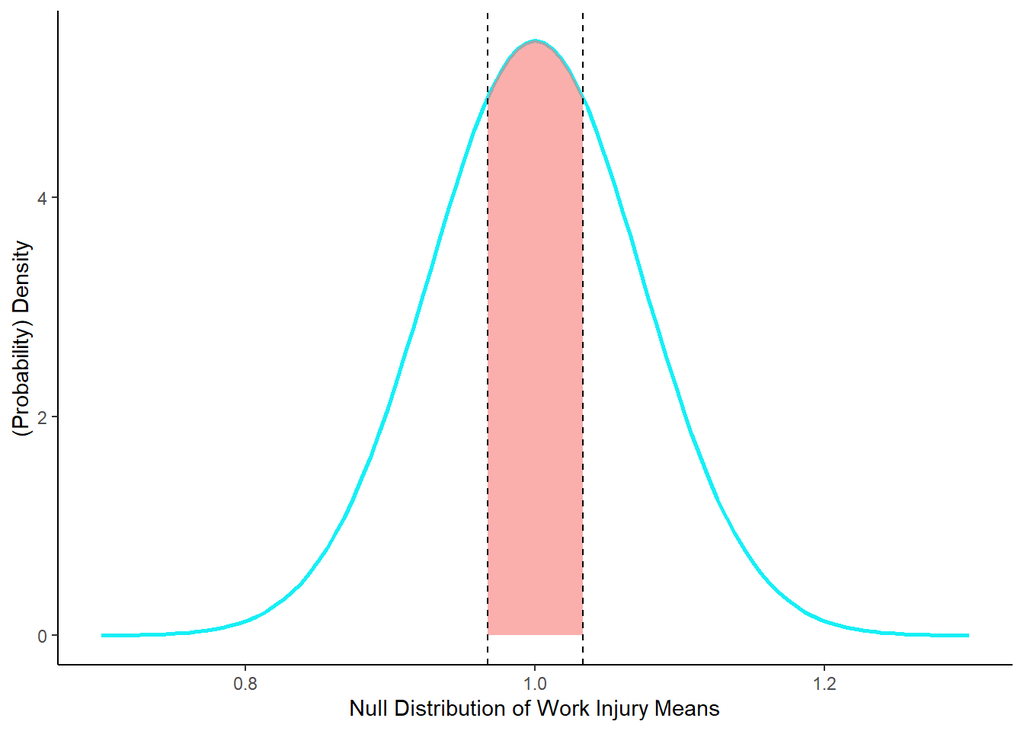

6. Visualizing the two-tailed hypothesis test, if the null hypothesis were true that the mean number of times our reference population takes off from work is once per month, the probability of obtaining the sample statistic at least as low as 0.967 or alternatively at least as high as 1.033 is quite probable at 65% of the time. In other words, our p-value corresponds to an area in the tail-ends of the null distribution that is quite large, and our observed result is pretty consistent with the expected value of the null distribution.